# 01_10C_Heart_Disease_Risk_Factors

### 심장병 - 정확도의 함정 ② (위험 요인 편)

### 학습 내용

- 기본 분석([01_10_Heart_Disease](https://ldjwj.github.io/dataAnalysis/01_10_Heart_Disease.html))에서 사용하지 않은 **범주형 변수**로 심장병 위험 요인 살펴보기
- 그룹별 비율을 볼 때 **표본 수**를 함께 확인하고, 순서가 있는 범주(연령대, 건강 자가평가)는 **순서를 지정**하여 비교하기
- 단순 비교와 **다른 변수를 함께 고려한 비교(로지스틱 회귀 오즈비)** 의 차이 이해하기

### 내용

- 0. 기본 분석 돌아보기 - 무엇을 보완할까?
- 1. 데이터 준비 (순서 지정, 구간 나누기)
- 2. 연령대와 성별
- 3. BMI 구간
- 4. 생활 습관 - 흡연, 음주, 신체활동, 수면시간
- 5. 질병 이력 - 뇌졸중, 당뇨, 신장질환, 걷기 어려움
- 6. 건강 자가평가(GenHealth)
- 7. 위험 요인 순위 - 로지스틱 회귀 오즈비
- 8. 정리

### 0. 기본 분석 돌아보기 - 무엇을 보완할까?

- 기본 분석은 **수치형 4개 변수**(BMI, PhysicalHealth, MentalHealth, SleepTime)만으로 모델을 만들었다.
  - 랜덤포레스트 테스트 정확도 0.914 = 전부 'No' 기준선과 같음 ([추가 분석 1편](https://ldjwj.github.io/dataAnalysis/01_10B_Heart_Disease_Accuracy_Trap_Modeling.html)에서 Yes 예측 0명 확인)
- 18개 열 중 **14개 범주형 변수**(연령대, 흡연, 뇌졸중, 당뇨, 건강 자가평가 등)는 탐색하지 않았다.
- 이번 분석에서는 **어떤 사람들에게서 심장병 비율이 높은지**를 변수별로 확인하고, 마지막에 요인의 순위를 정리한다.
- 주의 : 이 데이터는 **설문 조사(횡단면) 데이터**이므로 "원인"이 아니라 **함께 나타나는 관계(연관성)** 를 본다.

### 필수 라이브러리 불러오기

```python
import pandas as pd
import numpy as np
import seaborn as sns
import matplotlib.pyplot as plt
import plotly.express as px
import plotly.io as pio
pio.renderers.default = 'notebook'   # HTML에 plotly.js 포함 (오프라인에서도 동작)
import warnings
warnings.filterwarnings('ignore')

from sklearn.linear_model import LogisticRegression

# 한글 폰트 설정
# - koreanize-matplotlib이 설치되어 있으면 OS와 상관없이 나눔고딕을 사용 (pip install koreanize-matplotlib)
# - 없으면 OS에 맞는 기본 한글 폰트를 사용
try:
    import koreanize_matplotlib
except ImportError:
    import platform
    plt.rcParams['font.family'] = {'Windows': 'Malgun Gothic',
                                   'Darwin': 'AppleGothic'}.get(platform.system(), 'NanumGothic')
plt.rcParams['axes.unicode_minus'] = False

sns.set_theme(style='whitegrid', font=plt.rcParams['font.family'])
```

### 1. 데이터 준비

```python
df = pd.read_csv("./data/HeartDisease/heart_2020_cleaned.csv")
df['심장병'] = (df['HeartDisease'] == 'Yes').astype(int)

print(df.shape)
print('전체 심장병 비율: {:.2%}'.format(df['심장병'].mean()))
```

```
(319795, 19)
전체 심장병 비율: 8.56%
```

- 한줄 확인 : 전체 **319,795명** 중 심장병(Yes)은 **8.56%** 이다. 이 비율(전체 평균)보다 높은 그룹이 위험 그룹이다.

#### 순서 지정과 구간 나누기

- `AgeCategory`, `GenHealth`는 순서가 있는 범주 → `Categorical(ordered=True)`로 지정해야 표와 그래프가 **나이순, 건강순**으로 나온다.
- BMI는 WHO 기준 구간, 수면시간은 시간 단위 구간으로 나눈다.

```python
age_order = ['18-24', '25-29', '30-34', '35-39', '40-44', '45-49', '50-54',
             '55-59', '60-64', '65-69', '70-74', '75-79', '80 or older']
gen_order = ['Excellent', 'Very good', 'Good', 'Fair', 'Poor']
df['AgeCategory'] = pd.Categorical(df['AgeCategory'], categories=age_order, ordered=True)
df['GenHealth'] = pd.Categorical(df['GenHealth'], categories=gen_order, ordered=True)

# BMI 구간 (WHO 기준)
df['BMI구간'] = pd.cut(df['BMI'], bins=[0, 18.5, 25, 30, 35, 40, 100], right=False,
                     labels=['저체중(<18.5)', '정상(18.5-25)', '과체중(25-30)',
                             '비만1(30-35)', '비만2(35-40)', '고도비만(40+)'])

# 수면시간 구간
df['수면구간'] = pd.cut(df['SleepTime'], bins=[0, 5, 6, 7, 8, 9, 24],
                     labels=['5시간 이하', '6시간', '7시간', '8시간', '9시간', '10시간 이상'])

df[['AgeCategory', 'GenHealth', 'BMI구간', '수면구간']].head()
```

|  | AgeCategory | GenHealth | BMI구간 | 수면구간 |
| --- | --- | --- | --- | --- |
| 0 | 55-59 | Very good | 저체중(<18.5) | 5시간 이하 |
| 1 | 80 or older | Very good | 정상(18.5-25) | 7시간 |
| 2 | 65-69 | Fair | 과체중(25-30) | 8시간 |
| 3 | 75-79 | Good | 정상(18.5-25) | 6시간 |
| 4 | 40-44 | Very good | 정상(18.5-25) | 8시간 |

#### 그룹별 심장병 비율 함수

- 비율만 보면 표본이 적은 그룹에 속기 쉽다 → **표본 수(명)** 를 항상 함께 출력

```python
def rate_table(col, data=df):
    t = data.groupby(col, observed=True)['심장병'].agg(표본수='size', 심장병수='sum', 비율='mean')
    t['비율(%)'] = (t.pop('비율') * 100).round(2)
    return t

rate_table('Sex')
```

| Sex | 표본수 | 심장병수 | 비율(%) |
| --- | --- | --- | --- |
| Female | 167805 | 11234 | 6.69 |
| Male | 151990 | 16139 | 10.62 |

- 한줄 확인 : 남성 **10.62%**, 여성 **6.69%** → 남성이 약 1.6배 높다. 두 그룹 모두 15만 명 이상으로 표본은 충분하다.

### 2. 연령대와 성별

```python
age_t = rate_table('AgeCategory')
age_t
```

| AgeCategory | 표본수 | 심장병수 | 비율(%) |
| --- | --- | --- | --- |
| 18-24 | 21064 | 130 | 0.62 |
| 25-29 | 16955 | 133 | 0.78 |
| 30-34 | 18753 | 226 | 1.21 |
| 35-39 | 20550 | 296 | 1.44 |
| 40-44 | 21006 | 486 | 2.31 |
| 45-49 | 21791 | 744 | 3.41 |
| 50-54 | 25382 | 1383 | 5.45 |
| 55-59 | 29757 | 2202 | 7.40 |
| 60-64 | 33686 | 3327 | 9.88 |
| 65-69 | 34151 | 4101 | 12.01 |
| 70-74 | 31065 | 4847 | 15.60 |
| 75-79 | 21482 | 4049 | 18.85 |
| 80 or older | 24153 | 5449 | 22.56 |

- 한줄 확인 : 18-24세 **0.62%** → 80세 이상 **22.56%**로 약 36배. 50대(5.45%)부터 빠르게 늘어나 60-64세 9.88%, 70-74세 15.60%. 모든 연령대의 표본이 1.6만 명 이상이다.

#### [인터랙티브] 연령대 × 성별 심장병 비율

- 마우스를 올리면 비율과 표본 수를 확인할 수 있다. (집계한 26개 점만 사용 → HTML 용량이 작다)

```python
age_sex = (df.groupby(['AgeCategory', 'Sex'], observed=True)['심장병']
             .agg(표본수='size', 비율='mean').reset_index())
age_sex['비율(%)'] = (age_sex['비율'] * 100).round(2)

fig = px.line(age_sex, x='AgeCategory', y='비율(%)', color='Sex', markers=True,
              hover_data={'표본수': ':,'}, title='연령대 × 성별 심장병 비율(%)',
              category_orders={'AgeCategory': age_order},
              labels={'AgeCategory': '연령대', 'Sex': '성별'})
fig.update_layout(height=420)
fig.show()
```

[interactive chart not shown]

- 한줄 확인 : 25-29세(남 0.74%, 여 0.83%)를 제외한 **모든 연령대에서 남성이 더 높고**, 차이는 나이가 들수록 커진다. 65-74세에서는 남성이 약 **2배**(65-69세 16.36% vs 8.13%)

### 3. BMI 구간

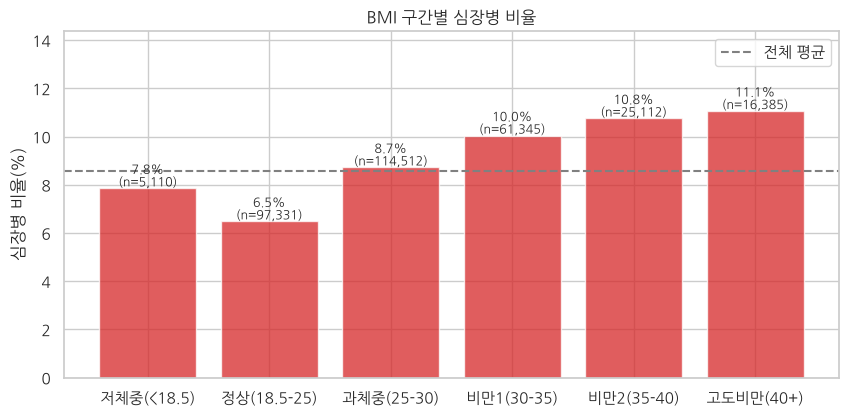

| BMI구간 | 표본수 | 심장병수 | 비율(%) |
| --- | --- | --- | --- |
| 저체중(<18.5) | 5110 | 401 | 7.85 |
| 정상(18.5-25) | 97331 | 6309 | 6.48 |
| 과체중(25-30) | 114512 | 9991 | 8.72 |
| 비만1(30-35) | 61345 | 6160 | 10.04 |
| 비만2(35-40) | 25112 | 2700 | 10.75 |
| 고도비만(40+) | 16385 | 1812 | 11.06 |

```python
bmi_t = rate_table('BMI구간')

fig, ax = plt.subplots(figsize=(10, 4.5))
bars = ax.bar(bmi_t.index.astype(str), bmi_t['비율(%)'], color='tab:red', alpha=0.75)
ax.bar_label(bars, labels=[f"{r:.1f}%\n(n={n:,})" for r, n in zip(bmi_t['비율(%)'], bmi_t['표본수'])], fontsize=9)
ax.axhline(df['심장병'].mean() * 100, color='gray', ls='--', label='전체 평균')
ax.set_title('BMI 구간별 심장병 비율')
ax.set_ylabel('심장병 비율(%)')
ax.set_ylim(0, bmi_t['비율(%)'].max() * 1.3)
ax.legend()
plt.show()
bmi_t
```

- 한줄 확인 : 정상 체중(18.5-25)이 **6.48%**로 가장 낮고, BMI가 높아질수록 증가하여 고도비만(40+)은 **11.06%**. 저체중(7.85%)도 정상보다 높다. (단, 저체중은 5,110명으로 표본이 가장 적다)

### 4. 생활 습관 - 흡연, 음주, 신체활동, 수면시간

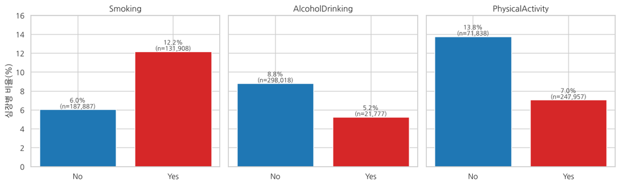

|  | Smoking | 표본수 | 심장병수 | 비율(%) |
| --- | --- | --- | --- | --- |
| Smoking | No | 187887 | 11336 | 6.03 |
|  | Yes | 131908 | 16037 | 12.16 |
| AlcoholDrinking | No | 298018 | 26232 | 8.80 |
|  | Yes | 21777 | 1141 | 5.24 |
| PhysicalActivity | No | 71838 | 9884 | 13.76 |
|  | Yes | 247957 | 17489 | 7.05 |

```python
habit_cols = ['Smoking', 'AlcoholDrinking', 'PhysicalActivity']
fig, axes = plt.subplots(1, 3, figsize=(13, 4), sharey=True)
for ax, col in zip(axes, habit_cols):
    t = rate_table(col)
    bars = ax.bar(t.index, t['비율(%)'], color=['tab:blue', 'tab:red'])
    ax.bar_label(bars, labels=[f"{r:.1f}%\n(n={n:,})" for r, n in zip(t['비율(%)'], t['표본수'])], fontsize=9)
    ax.set_title(col)
axes[0].set_ylabel('심장병 비율(%)')
axes[0].set_ylim(0, 16)
plt.tight_layout()
plt.show()

pd.concat({c: rate_table(c) for c in habit_cols})
```

- 한줄 확인 : 흡연자 **12.16%** vs 비흡연자 6.03% (약 2배), 신체활동 없음 **13.76%** vs 있음 7.05%. 그런데 **음주자(5.24%)가 비음주자(8.80%)보다 낮다** → 상식과 다른 결과이므로 아래에서 확인

#### 음주자의 심장병 비율이 더 낮다? - 나이를 함께 보기

- 단순 비교 결과가 상식과 다를 때는 **다른 변수(혼재 변수)** 가 영향을 주지 않는지 확인한다.

```python
# 연령대별 음주 비율
drink_by_age = (df['AlcoholDrinking'] == 'Yes').groupby(df['AgeCategory'], observed=True).mean().mul(100).round(1)

# 같은 연령대 안에서 음주 여부별 심장병 비율
age_drink = df.pivot_table(index='AgeCategory', columns='AlcoholDrinking', values='심장병',
                           aggfunc='mean', observed=True).mul(100).round(2)
age_drink['음주율(%)'] = drink_by_age
age_drink
```

| AlcoholDrinking AgeCategory | No | Yes | 음주율(%) |
| --- | --- | --- | --- |
| 18-24 | 0.62 | 0.59 | 7.2 |
| 25-29 | 0.76 | 1.02 | 9.3 |
| 30-34 | 1.19 | 1.33 | 8.4 |
| 35-39 | 1.45 | 1.37 | 8.9 |
| 40-44 | 2.32 | 2.27 | 8.6 |
| 45-49 | 3.49 | 2.55 | 7.7 |
| 50-54 | 5.46 | 5.26 | 7.7 |
| 55-59 | 7.49 | 6.22 | 7.5 |
| 60-64 | 10.12 | 6.56 | 6.9 |
| 65-69 | 12.26 | 8.23 | 6.2 |
| 70-74 | 15.90 | 10.14 | 5.1 |
| 75-79 | 19.11 | 12.87 | 4.2 |
| 80 or older | 22.62 | 20.67 | 2.8 |

- 한줄 확인 : 음주율은 18-24세 7.2% → 80세 이상 2.8%로 **나이가 많을수록 낮다.** 심장병이 많은 고령층에 비음주자가 많으므로, 단순 비교에서는 음주자의 비율이 낮게 보인다. 그래도 **45세 이상 모든 연령대에서 음주자의 비율이 더 낮다.**
  - 이 데이터의 `AlcoholDrinking`은 **과음 여부**(남성 주 14잔, 여성 주 7잔 초과)이며, 설문 데이터이므로 "이미 병이 있어서 술을 끊은 사람"이 비음주자에 포함되었을 수 있다. → **음주가 심장병을 막는다고 해석하면 안 된다.**

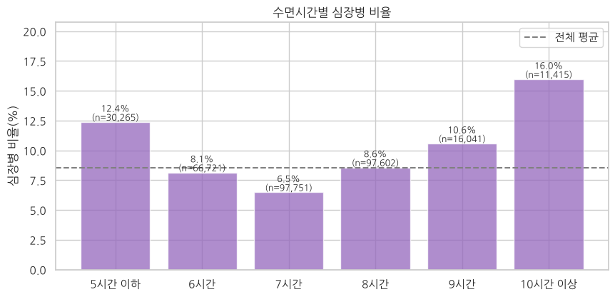

| 수면구간 | 표본수 | 심장병수 | 비율(%) |
| --- | --- | --- | --- |
| 5시간 이하 | 30265 | 3745 | 12.37 |
| 6시간 | 66721 | 5427 | 8.13 |
| 7시간 | 97751 | 6325 | 6.47 |
| 8시간 | 97602 | 8358 | 8.56 |
| 9시간 | 16041 | 1696 | 10.57 |
| 10시간 이상 | 11415 | 1822 | 15.96 |

```python
sleep_t = rate_table('수면구간')

fig, ax = plt.subplots(figsize=(10, 4.5))
bars = ax.bar(sleep_t.index.astype(str), sleep_t['비율(%)'], color='tab:purple', alpha=0.75)
ax.bar_label(bars, labels=[f"{r:.1f}%\n(n={n:,})" for r, n in zip(sleep_t['비율(%)'], sleep_t['표본수'])], fontsize=9)
ax.axhline(df['심장병'].mean() * 100, color='gray', ls='--', label='전체 평균')
ax.set_title('수면시간별 심장병 비율')
ax.set_ylabel('심장병 비율(%)')
ax.set_ylim(0, sleep_t['비율(%)'].max() * 1.3)
ax.legend()
plt.show()
sleep_t
```

- 한줄 확인 : **7시간**이 6.47%로 가장 낮고, 5시간 이하(12.37%)와 10시간 이상(**15.96%**)이 높은 **U자형**. 잠이 너무 짧거나 너무 긴 경우 모두 위험 그룹이다.

### 5. 질병 이력 - 뇌졸중, 당뇨, 신장질환, 걷기 어려움

```python
disease_cols = ['Stroke', 'Diabetic', 'KidneyDisease', 'DiffWalking']
disease_t = pd.concat({c: rate_table(c) for c in disease_cols})
disease_t
```

|  |  | 표본수 | 심장병수 | 비율(%) |
| --- | --- | --- | --- | --- |
| Stroke | No | 307726 | 22984 | 7.47 |
|  | Yes | 12069 | 4389 | 36.37 |
| Diabetic | No | 269653 | 17519 | 6.50 |
|  | No, borderline diabetes | 6781 | 789 | 11.64 |
|  | Yes | 40802 | 8957 | 21.95 |
|  | Yes (during pregnancy) | 2559 | 108 | 4.22 |
| KidneyDisease | No | 308016 | 23918 | 7.77 |
|  | Yes | 11779 | 3455 | 29.33 |
| DiffWalking | No | 275385 | 17345 | 6.30 |
|  | Yes | 44410 | 10028 | 22.58 |

- 한줄 확인 : 뇌졸중 경험자 **36.37%**(경험 없음 7.47%의 약 4.9배), 신장질환 29.33%, 걷기 어려움 22.58%, 당뇨 21.95%. 경계성 당뇨도 11.64%로 평균보다 높다. 임신성 당뇨(4.22%)는 대부분 젊은 여성이라 낮다. (표본 2,559명)

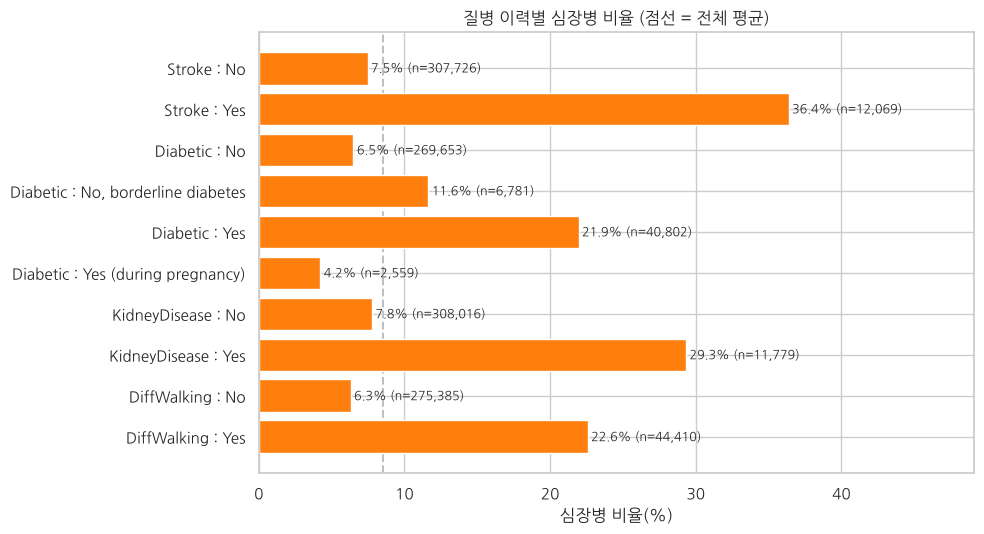

```python
# 위 표를 한 그래프로 (그룹별 비율, 막대 옆에 표본 수)
plot_t = disease_t.reset_index()
plot_t['그룹'] = plot_t['level_0'] + ' : ' + plot_t['level_1'].astype(str)

fig, ax = plt.subplots(figsize=(10, 5.5))
bars = ax.barh(plot_t['그룹'], plot_t['비율(%)'], color='tab:orange')
ax.bar_label(bars, labels=[f" {r:.1f}% (n={n:,})" for r, n in zip(plot_t['비율(%)'], plot_t['표본수'])], fontsize=9)
ax.axvline(df['심장병'].mean() * 100, color='gray', ls='--', alpha=0.5, zorder=0)
ax.invert_yaxis()
ax.set_xlim(0, plot_t['비율(%)'].max() * 1.35)
ax.set_xlabel('심장병 비율(%)')
ax.set_title('질병 이력별 심장병 비율 (점선 = 전체 평균)')
plt.tight_layout()
plt.show()
```

- 한줄 확인 : 임신성 당뇨를 제외한 모든 '질병 있음' 그룹이 전체 평균(8.56%)보다 높고, 특히 **뇌졸중 경험자는 3명 중 1명 이상**이 심장병을 가지고 있다.

### 6. 건강 자가평가(GenHealth)

```python
rate_table('GenHealth')
```

| GenHealth | 표본수 | 심장병수 | 비율(%) |
| --- | --- | --- | --- |
| Excellent | 66842 | 1500 | 2.24 |
| Very good | 113858 | 5381 | 4.73 |
| Good | 93129 | 9558 | 10.26 |
| Fair | 34677 | 7084 | 20.43 |
| Poor | 11289 | 3850 | 34.10 |

- 한줄 확인 : 건강 자가평가가 Excellent **2.24%** → Very good 4.73% → Good 10.26% → Fair 20.43% → Poor **34.10%**. 한 단계 나빠질 때마다 약 **1.7~2.2배**씩 높아진다.

#### [인터랙티브] 연령대 × 건강 자가평가 히트맵

- 나이가 많을수록 건강 자가평가가 나빠지므로, 두 변수를 **함께** 보아야 각각의 효과를 알 수 있다.

```python
heat = df.pivot_table(index='GenHealth', columns='AgeCategory', values='심장병',
                      aggfunc='mean', observed=True).mul(100).round(1)
heat_n = df.pivot_table(index='GenHealth', columns='AgeCategory', values='심장병',
                        aggfunc='size', observed=True)

fig = px.imshow(heat, text_auto=True, color_continuous_scale='Reds', aspect='auto',
                labels={'x': '연령대', 'y': '건강 자가평가', 'color': '비율(%)'},
                title='연령대 × 건강 자가평가별 심장병 비율(%)')
fig.update_traces(customdata=heat_n.values,
                  hovertemplate='연령대 %{x}<br>건강 %{y}<br>비율 %{z}%<br>표본 수 %{customdata:,}명<extra></extra>')
fig.update_layout(height=430)
fig.show()
```

[interactive chart not shown]

- 한줄 확인 : 같은 연령대 안에서도 **Poor > Fair > Good** 순서가 모든 연령대에서 유지된다. 80세 이상이라도 Excellent는 10.8%로, 50-54세 Poor(28.1%)보다 훨씬 낮다. 가장 높은 칸은 75-79세 Poor(**45.5%**)

```python
# 표본이 적은 칸 확인
heat_n.min().min(), heat_n.stack().idxmin()
```

```
(np.int64(148), ('Poor', '18-24'))
```

- 한줄 확인 : 표본이 가장 적은 칸은 18-24세 × Poor로 **148명**. 모든 칸이 100명 이상이라 비율 비교가 가능하다. (비율이 극단적인 칸은 표본 수를 마우스로 확인)

### 7. 위험 요인 순위 - 로지스틱 회귀 오즈비

- 단순 비율 비교는 다른 변수의 영향(예: 나이)이 섞여 있다.
- 로지스틱 회귀에 변수를 **함께** 넣으면, 각 계수는 **다른 변수가 같을 때**의 효과가 된다.
- **오즈비(Odds Ratio) = exp(계수)** : 1보다 크면 위험 증가, 1보다 작으면 위험 감소
  - 예) 오즈비 2 → (다른 조건이 같을 때) 심장병 오즈가 2배
- 해석하기 쉽도록 단위를 정한다 : 연령 **10세당**, BMI **5당**, 신체/정신 건강이 나쁜 날 **10일당**
- 범주형은 **기준 그룹**과 비교 : GenHealth=Excellent, Diabetic=No, 수면=7시간, Race=White
- 전체 319,795행 사용 (모델이 가벼워 수 초면 학습)

```python
# 연령대 → 대표 나이(구간 중앙값), 10세 단위
age_mid = {a: (int(a[:2]) + int(a[-2:])) / 2 for a in age_order[:-1]}
age_mid['80 or older'] = 82

X = pd.DataFrame({
    '연령(10세당)': df['AgeCategory'].astype(str).map(age_mid) / 10,
    'BMI(5당)': df['BMI'] / 5,
    '신체건강 나쁜 날(10일당)': df['PhysicalHealth'] / 10,
    '정신건강 나쁜 날(10일당)': df['MentalHealth'] / 10,
    '남성': (df['Sex'] == 'Male').astype(int),
})
for col in ['Smoking', 'AlcoholDrinking', 'Stroke', 'DiffWalking', 'PhysicalActivity',
            'Asthma', 'KidneyDisease', 'SkinCancer']:
    X[col] = (df[col] == 'Yes').astype(int)

# 범주형 : 기준 그룹을 빼고 더미 변수 생성
def dummies(s, ref, prefix):
    d = pd.get_dummies(s.astype(str), prefix=prefix, prefix_sep=': ', dtype=int)
    return d.drop(columns=f'{prefix}: {ref}')

X = pd.concat([X,
               dummies(df['GenHealth'], 'Excellent', 'GenHealth'),
               dummies(df['Diabetic'], 'No', 'Diabetic'),
               dummies(df['수면구간'], '7시간', '수면'),
               dummies(df['Race'], 'White', 'Race')], axis=1)
print(X.shape)
```

```
(319795, 30)
```

```python
logit = LogisticRegression(C=1e6, max_iter=3000)   # C를 크게 → 규제가 거의 없는 일반 로지스틱 회귀
logit.fit(X, df['심장병'])

odds = pd.DataFrame({'계수': logit.coef_[0], '오즈비': np.exp(logit.coef_[0])}, index=X.columns)
odds['영향 크기'] = odds['계수'].abs()          # 위험을 낮추는 요인도 같은 기준으로 비교
odds = odds.sort_values('영향 크기', ascending=False).round(3)
odds
```

|  | 계수 | 오즈비 | 영향 크기 |
| --- | --- | --- | --- |
| GenHealth: Poor | 1.882 | 6.568 | 1.882 |
| GenHealth: Fair | 1.516 | 4.552 | 1.516 |
| GenHealth: Good | 1.041 | 2.833 | 1.041 |
| Stroke | 1.040 | 2.829 | 1.040 |
| 남성 | 0.713 | 2.040 | 0.713 |
| KidneyDisease | 0.559 | 1.748 | 0.559 |
| Race: Asian | -0.553 | 0.575 | 0.553 |
| 연령(10세당) | 0.540 | 1.715 | 0.540 |
| Diabetic: Yes | 0.478 | 1.612 | 0.478 |
| GenHealth: Very good | 0.472 | 1.603 | 0.472 |
| Smoking | 0.351 | 1.420 | 0.351 |
| Race: Black | -0.288 | 0.750 | 0.288 |
| 수면: 5시간 이하 | 0.273 | 1.314 | 0.273 |
| Asthma | 0.273 | 1.313 | 0.273 |
| AlcoholDrinking | -0.254 | 0.776 | 0.254 |
| Race: Hispanic | -0.202 | 0.817 | 0.202 |
| DiffWalking | 0.199 | 1.220 | 0.199 |
| Diabetic: No, borderline diabetes | 0.124 | 1.131 | 0.124 |
| SkinCancer | 0.109 | 1.115 | 0.109 |
| 수면: 6시간 | 0.094 | 1.099 | 0.094 |
| 수면: 10시간 이상 | 0.085 | 1.089 | 0.085 |
| Race: American Indian/Alaskan Native | 0.079 | 1.082 | 0.079 |
| 수면: 9시간 | 0.057 | 1.058 | 0.057 |
| 수면: 8시간 | 0.054 | 1.055 | 0.054 |
| BMI(5당) | 0.046 | 1.047 | 0.046 |
| 정신건강 나쁜 날(10일당) | 0.040 | 1.041 | 0.040 |
| 신체건강 나쁜 날(10일당) | 0.029 | 1.030 | 0.029 |
| PhysicalActivity | 0.028 | 1.029 | 0.028 |
| Diabetic: Yes (during pregnancy) | 0.016 | 1.016 | 0.016 |
| Race: Other | 0.008 | 1.008 | 0.008 |

- 한줄 확인 : 다른 변수를 함께 고려하면 **건강 자가평가 Poor(오즈비 6.57), Fair(4.55), Good(2.83)**, **뇌졸중(2.83)**, **남성(2.04)**, 신장질환(1.75), 연령 10세당(1.72), 당뇨(1.61), 흡연(1.42) 순으로 영향이 크다.
  - 반면 **신체활동(1.03), BMI 5당(1.05)** 은 다른 변수를 고려하면 영향이 거의 사라진다.

#### 주의 - 오즈비의 크기는 "단위"에 따라 달라진다

- 연령의 오즈비 1.7은 **10세당** 값이다. 18-24세와 80세 이상은 약 60세 차이 → 10세 단위 6번이 쌓인다.

```python
print('반복 횟수(수렴 확인):', logit.n_iter_[0])
or_age = odds.loc['연령(10세당)', '오즈비']
print(f'연령 10세당 오즈비 : {or_age:.3f}')
print(f'21세 → 82세(약 6.1 × 10세) 오즈비 : {or_age ** 6.1:.1f}')
print(f'BMI 20 → 40 (5 × 4단위) 오즈비 : {odds.loc["BMI(5당)", "오즈비"] ** 4:.2f}')
```

```
반복 횟수(수렴 확인): 94
연령 10세당 오즈비 : 1.715
21세 → 82세(약 6.1 × 10세) 오즈비 : 26.9
BMI 20 → 40 (5 × 4단위) 오즈비 : 1.20
```

- 한줄 확인 : 반복 94번에서 수렴했다. 연령의 오즈비는 10세당 1.715지만 21세 → 82세로 보면 **약 26.9배**로, 범위 전체를 보면 **나이가 가장 강한 요인**이다. 반대로 BMI는 20 → 40으로 커져도 오즈비 1.20에 그친다.

#### [인터랙티브] 오즈비 순위 (Race 제외)

- 가로축은 로그 눈금 : 1(점선)보다 오른쪽은 위험 증가, 왼쪽은 위험 감소

```python
plot_odds = odds[~odds.index.str.startswith('Race')].reset_index(names='요인')
plot_odds['방향'] = np.where(plot_odds['오즈비'] > 1, '위험 증가', '위험 감소')

fig = px.bar(plot_odds.sort_values('영향 크기'), x='오즈비', y='요인', color='방향', orientation='h',
             log_x=True, text='오즈비', color_discrete_map={'위험 증가': '#d62728', '위험 감소': '#1f77b4'},
             title='심장병 요인별 오즈비 (다른 변수를 함께 고려, 로그 눈금)')
fig.add_vline(x=1, line_dash='dash', line_color='gray')
fig.update_traces(texttemplate='%{text:.2f}', textposition='outside', cliponaxis=False)
fig.update_layout(height=700, yaxis_title='', legend_title='', xaxis_range=[np.log10(0.6), np.log10(10)])
fig.show()
```

[interactive chart not shown]

- 한줄 확인 : 빨간 막대(위험 증가)는 건강 자가평가, 뇌졸중, 성별, 신장질환, 연령이 위쪽을 차지하고, 파란 막대(위험 감소)는 과음(0.78)뿐이다. (Race는 그래프에서 제외, 위 표 참고)

#### 단순 비교 vs 다른 변수를 함께 고려한 비교

- 단순 비교 : 해당 그룹 비율 ÷ 아닌 그룹 비율 (비율의 배수)
- 오즈비 : 로지스틱 회귀 결과 (나이, 건강 상태 등이 같다고 할 때)

```python
compare = []
for col in ['Stroke', 'KidneyDisease', 'DiffWalking', 'Smoking', 'AlcoholDrinking', 'PhysicalActivity']:
    r = df.groupby(col)['심장병'].mean()
    compare.append({'요인': col, '비율(Yes)%': r['Yes'] * 100, '비율(No)%': r['No'] * 100,
                    '단순 비율 배수': r['Yes'] / r['No'], '오즈비(함께 고려)': odds.loc[col, '오즈비']})
pd.DataFrame(compare).round(2)
```

|  | 요인 | 비율(Yes)% | 비율(No)% | 단순 비율 배수 | 오즈비(함께 고려) |
| --- | --- | --- | --- | --- | --- |
| 0 | Stroke | 36.37 | 7.47 | 4.87 | 2.83 |
| 1 | KidneyDisease | 29.33 | 7.77 | 3.78 | 1.75 |
| 2 | DiffWalking | 22.58 | 6.30 | 3.59 | 1.22 |
| 3 | Smoking | 12.16 | 6.03 | 2.02 | 1.42 |
| 4 | AlcoholDrinking | 5.24 | 8.80 | 0.60 | 0.78 |
| 5 | PhysicalActivity | 7.05 | 13.76 | 0.51 | 1.03 |

- 한줄 확인 : 단순 비교에서는 뇌졸중 4.87배, 신장질환 3.78배, 걷기 어려움 3.59배였지만, 다른 변수를 함께 고려하면 오즈비 **2.83, 1.75, 1.22**로 줄어든다. → 나이·건강 상태가 겹쳐 있던 몫이 빠진 것
  - 신체활동은 단순 비교 0.51(위험 절반)이었지만 함께 고려하면 **1.03(거의 영향 없음)**. 신체활동을 안 하는 사람은 나이가 많고 건강 상태가 나쁜 경우가 많기 때문으로 볼 수 있다.

### 8. 정리

| 질문 | 기본 분석 | 추가 분석 결과 |
| --- | --- | --- |
| 어떤 변수를 사용했나? | 수치형 4개 (BMI, 신체/정신 건강, 수면) | 범주형 13개 포함 전체 17개 변수 |
| 나이에 따라 얼마나 다를까? | - | 18-24세 0.62% → 80세 이상 22.56% (약 36배), 남성이 거의 모든 연령대에서 높음 |
| 건강 자가평가는? | - | Excellent 2.24% → Poor 34.10%. 같은 연령대 안에서도 Poor > Fair > Good 유지 |
| 질병 이력은? | - | 뇌졸중 36.37%, 신장질환 29.33%, 걷기 어려움 22.58%, 당뇨 21.95% |
| 생활 습관은? | - | 흡연 12.16% vs 6.03%, 수면 7시간이 가장 낮은 U자형(6.47%), 과음자가 더 낮게 보이는 것은 나이·역인과 영향 가능 |
| BMI는? | 수치형 변수로만 사용 | 정상 6.48% → 고도비만 11.06%. 다른 변수를 고려하면 BMI 5당 오즈비 1.05로 작음 |
| 가장 강한 요인은? | - | 범위 전체로는 **나이**(21→82세 오즈비 약 26.9), 그다음 **건강 자가평가 Poor 6.57, 뇌졸중 2.83, 남성 2.04** |

#### 배운 점

- 그룹별 비율은 항상 **표본 수**와 함께 보고, 순서가 있는 범주는 `Categorical(ordered=True)`로 **순서를 지정**한다.
- 단순 비교 결과(음주, 신체활동)는 **나이 같은 혼재 변수**의 영향을 받는다. 변수를 함께 고려하는 **로지스틱 회귀 오즈비**로 다시 확인하자.
- 오즈비의 크기는 **단위**(10세당, BMI 5당)에 따라 달라지므로, 순위를 비교할 때는 단위와 실제 범위를 함께 본다.
- 설문(횡단면) 데이터의 결과는 **연관성**이며, 원인으로 해석하지 않는다.

#### 다음에 해 볼 분석

- 위험 요인 상위 변수만으로 예측 모델을 만들고 [추가 분석 1편](https://ldjwj.github.io/dataAnalysis/01_10B_Heart_Disease_Accuracy_Trap_Modeling.html)의 성능(ROC-AUC 0.838)과 비교
- 연령대 × 성별처럼 **상호작용**(예: 남성의 위험이 나이에 따라 달라지는지)을 모델에 넣어 보기
- 순열 중요도(permutation importance)로 트리 모델의 변수 중요도와 오즈비 순위 비교